# A Statistical Analysis of Donald Trump's Twitter Usage

### By Jeremy Tuthill

If you live in the United States of America, have lived there, or even follow our news with some regularity, you may have noticed that our president uses Twitter quite a bit. When he’s worked up over some “FAKE NEWS” or has some new thoughts on #CrookedHillary, he doesn’t hesitate to tell us about it, and this has caused a great deal of controversy over many aspects of his Twitter usage. People have accused him of violating the constitution by blocking people on Twitter (and there was actually an [official ruling](https://www.nytimes.com/2018/05/23/business/media/trump-twitter-block.html) later that confirmed this argument). Several Trump tweets have drawn intense scrutiny for their content: he accused president Obama of [wiretapping Trump Tower](https://twitter.com/realDonaldTrump/status/837989835818287106), he has repeatedly called the mainstream American press the [“enemy of the people”](https://twitter.com/realDonaldTrump/status/832708293516632065), and he has also used the social media platform to call out several famous people ([LeBron James](https://twitter.com/realDonaldTrump/status/1025586524782559232) and [Mark Cuban](https://twitter.com/realDonaldTrump/status/830769247185952772) are two examples).

```python
# LIBRARIES USED

!pip install wordcloud

import csv
import datetime
import matplotlib.pyplot as plt
import pandas as pd
import re
import requests
import seaborn as sns
import string

from wordcloud import WordCloud
```

```
You are using pip version 9.0.3, however version 18.1 is available.
```

## Data Collection

The Trump Twitter Archive allowed me to view all of its data in a comma-separated text box, which I then copied and pasted into a text file named trump_tweets.txt. This made it trivial to extract into a Pandas dataframe, which I do so here. The "ISO-8859-1" encoding was necessary because the read_csv function could not parse non-ASCII characters without it, but the characters remained in the dataframe as blank squares (or at least that's how they rendered here).

```python
# create dataframe using values from comma-separated text file
tweets = pd.read_csv('trump_tweets.txt', encoding = "ISO-8859-1")
tweets.head()
```

|  | text | created_at |
| --- | --- | --- |
| 0 | Just did an interview with @HARRISFAULKNER on ... | 12-13-2018 18:00:44 |
| 1 | ....She will probably be given a pass despite ... | 12-13-2018 17:34:15 |
| 2 | If it was a Conservative that said what craze... | 12-13-2018 17:34:14 |
| 3 | WITCH HUNT! | 12-13-2018 16:08:16 |
| 4 | They gave General Flynn a great deal because t... | 12-13-2018 16:07:50 |

## Data Cleaning

There were a few things that I needed to do in order to make the data neat and tidy.

- There were a variety of special characters in Trump tweets that were not able to be rendered in the Jupyter data science notebook. To deal with them, I simply removed any non-alphanumeric characters from all the Trump tweets. Normally, I might go through a slightly more difficult process to leave the punctuation in, but I knew ahead of time that I wasn’t going to use the punctuation for anything anyway.
- All the tweets’ timestamps were stored as strings. Of course, dates are far easier to manipulate when they are stored in the form of Python’s datetime objects, so I made this transition.
- The information was initially stored in reverse-chronological order, and I knew I needed to visualize the data in the form of some time-based plots, so I sorted the data chronologically to account for this. There were four tweets that did not have timestamps for whatever reason, so I omitted them to simplify things (since they were only 4 tweets out of over 33 thousand).

```python
# iterate through dataframe
for i, row in tweets.iterrows():
    # remove any characters in the text that can't be displayed
    cur_string = row['text']
    tweets.at[i, 'text'] = re.sub(r'[^\w]', ' ', cur_string)

    # convert created_at strings to datetime format
    tweets.at[i, 'created_at'] = pd.to_datetime(row['created_at'], format = '%m-%d-%Y %H:%M:%S', errors = 'ignore')

# sort the dataframe by date (because it was reverse sorted before)
tweets = tweets.sort_values(by = ['created_at'])

# drop the last 4 rows because they do not have timestamps
tweets = tweets.drop(tweets.tail(4).index)

tweets.head()
```

|  | text | created_at |
| --- | --- | --- |
| 33225 | Be sure to tune in and watch Donald Trump on L... | 2009-05-04 18:54:25 |
| 33224 | Donald Trump will be appearing on The View tom... | 2009-05-05 01:00:10 |
| 33223 | Donald Trump reads Top Ten Financial Tips on L... | 2009-05-08 13:38:08 |
| 33222 | New Blog Post Celebrity Apprentice Finale and... | 2009-05-08 20:40:15 |
| 33221 | My persona will never be that of a wallflower ... | 2009-05-12 14:07:28 |

## Data Visualization and Analysis

In order to get a sense of what Trump usually tweets about, I thought it would be useful to visualize the key words that he most often uses in the form of a word cloud. For this purpose, I found a very useful third-party library called word_cloud by Github user amueller. Though there are many options to create really cool word clouds (one of his examples was a word cloud of the script to Star Wars: A New Hope, and the cloud was made in the shape of a stormtrooper helmet), I was content with just the basics, so I used his most simple function to generate a word cloud for Trump’s tweets over four time periods: before he ran for president, while he was running for president, while he was president-elect, and while he has been president. This resulted in some interesting findings.

Because the function to create a word cloud takes a string, I compiled this information by creating a string for each of the time periods I mentioned and creating a date variable for each of the dates that marked the end of one of those time periods: the day Trump announced his candidacy, election day, and inauguration day. I then traversed the entire dataframe, concatenating each tweet’s text with the appropriate string, depending on the date the tweet was posted.

```python
# I want to create a wordcloud of Trump's tweets so we can get an idea of what he tweets about.

# These four strings will hold all of the words in his tweets over four intervals: before he ran for president, while he was
# running for president, while he was the president-elect, and after he was inaugurated.
pre_campaign_str = ""
candidacy_str = ""
president_elect_str = ""
president_str = ""

# The three major dates that will separate the data
announcement_date = datetime.date(2015, 6, 16)
election_date = datetime.date(2016, 11, 8)
inauguration_date = datetime.date(2017, 1, 20)

# add the text of each tweet to its respective string
for i, row in tweets.iterrows():
    if row['created_at'].date() < announcement_date:
        pre_campaign_str = pre_campaign_str + " " + row['text']
    elif row['created_at'].date() < election_date:
        candidacy_str = candidacy_str + " " + row['text']
    elif row['created_at'].date() < inauguration_date:
        president_elect_str = president_elect_str + " " + row['text']
    else:
        president_str = president_str + " " + row['text']
```

With the data in a format that was compatible with amueller's wordcloud function, I then created a word cloud for each of the time periods that I mentioned. I limited the word clouds to 50 words to keep them from getting too cluttered.

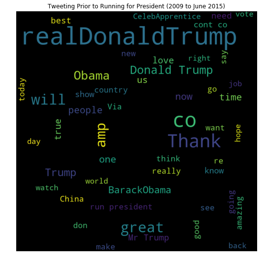

```python
# create wordcloud
pre_campaign_wordcloud = WordCloud(width = 800, height = 800, margin = 0, max_words = 50).generate(pre_campaign_str)

# display wordcloud
plt.figure(figsize = (9, 9))
plt.imshow(pre_campaign_wordcloud, interpolation = 'bilinear')
plt.axis("off")
plt.margins(x = 0, y = 0)
plt.title("Tweeting Prior to Running for President (2009 to June 2015)")
plt.show()
```

[figure not shown]

```python
# create wordcloud
candidacy_wordcloud = WordCloud(width = 800, height = 800, margin = 0, max_words = 50).generate(candidacy_str)

# display wordcloud
plt.figure(figsize = (9, 9))
plt.imshow(candidacy_wordcloud, interpolation = 'bilinear')
plt.axis("off")
plt.margins(x = 0, y = 0)
plt.title("Tweeting While Campaigning for President (June 2015 to November 2016)")
plt.show()
```

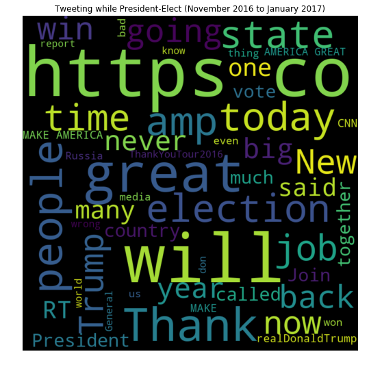

```python
# create wordcloud
president_elect_wordcloud = WordCloud(width = 800, height = 800, margin = 0, max_words = 50).generate(president_elect_str)

# display wordcloud
plt.figure(figsize = (9, 9))
plt.imshow(president_elect_wordcloud, interpolation = 'bilinear')
plt.axis("off")
plt.margins(x = 0, y = 0)
plt.title("Tweeting while President-Elect (November 2016 to January 2017)")
plt.show()
```

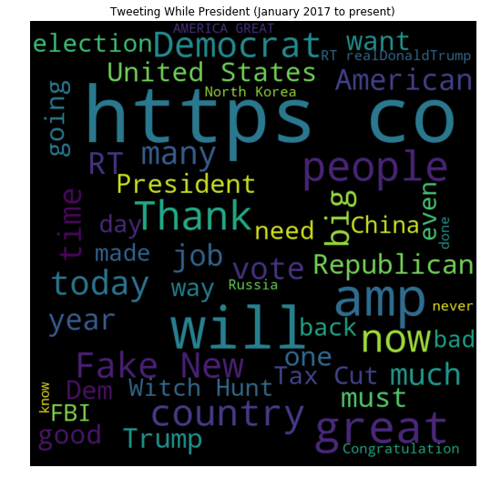

```python
# create wordcloud
president_wordcloud = WordCloud(width = 800, height = 800, margin = 0, max_words = 50).generate(president_str)

# display wordcloud
plt.figure(figsize = (9, 9))
plt.imshow(president_wordcloud, interpolation = 'bilinear')
plt.axis("off")
plt.margins(x = 0, y = 0)
plt.title("Tweeting While President (January 2017 to present)")
plt.show()
```

In examining the word clouds, this is what stands out to me:

- Prior to running for president, Donald Trump didn’t seem to tweet about much. A few notable words and phrases are “celeb apprentice”, “run president”, and “Obama”. This suggests that Trump mainly used Twitter to promote his show, [The Celebrity Apprentice](https://en.wikipedia.org/wiki/The_Celebrity_Apprentice), and to trash talk President Obama (because we know that Donald Trump was never a fan of Obama, especially since he helped popularize the [“birther” conspiracy theories](https://en.wikipedia.org/wiki/Barack_Obama_citizenship_conspiracy_theories#Donald_Trump) that centered around Obama. It’s also clear that Trump used the platform to float the idea of his presidential campaign.
- While Trump was campaigning for the presidency, the words and phrases that stand out to me are the different permutations of “Make America Great Again”, as well as mentions of “(Crooked) Hillary” and CNN ([his favorite news outlet to criticize](https://thehill.com/homenews/media/396858-trump-i-dont-take-questions-from-cnn)). This definitely shows that his primary focus during the campaign was to get his voting base energized with his trademark slogan and his attacks aimed at his likely general election opponent and his biggest enemy in the media (at least in his perception).
- Once Trump had won the election, it seems that his Twitter feed cooled off a bit. There was still a significant focus on the phrase “Make America Great Again”, but there is not much that stands out otherwise. He did talk about the election quite a bit, which is likely because many questioned its legitimacy due to accusations of [Russian interference](https://en.wikipedia.org/wiki/Russian_interference_in_the_2016_United_States_elections) and also due to the fact that Trump lost the popular vote by about [3 million votes](https://www.270towin.com/2016_Election/).
- Now that Trump is president, his tweeting has focused on a variety of subjects. He tweets a lot about “fake news”, which is generally his response to negative articles about him. He tweets a lot about the Democrats, which makes sense because they are his political opponents and he likes to accuse them of obstructionism. Other notable phrases are “witch hunt” (I think that one speaks for itself), “China” ([his least favorite country](https://www.politifact.com/truth-o-meter/statements/2016/jun/03/hillary-clinton/yes-donald-trump-did-call-climate-change-chinese-h/)), and “election” (which I infer to be residual discussion regarding his election and its legitimacy).

Overall, I think that the four word clouds are all pretty good representations of the issues most relevant to Trump at any given time.

The next step in my analysis was looking at the volume of tweets posted by Trump and comparing it across time periods, as well as identifying key dates on which Trump tweeted many times. To accomplish this, I first extracted all the unique dates on which Trump tweeted and created a dataframe indexed by those dates. I then iterated through the main dataframe, counting the number of tweets on each day and storing that information in the new dataframe. This gave me the data in a format that I could easily visualize.

```python
# get a list of dates on which Trump tweeted

tweet_datetimes = tweets['created_at'].unique()
tweet_dates = []

# create a list of all unique dates on which a tweet was posted
for timestamp in tweet_datetimes:
    if not timestamp.date() in tweet_dates:
        tweet_dates.append(timestamp.date())

# create dataframe with one row for each date with a tweet
tweets_by_date = pd.DataFrame(tweet_dates, columns = ['date'])
tweets_by_date = tweets_by_date.set_index('date')
tweets_by_date['num_tweets'] = 0

# count the number of tweets on each day
for i, row in tweets.iterrows():
    tweets_by_date.at[row['created_at'].date(), 'num_tweets'] += 1

tweets_by_date.head()
```

| date | num_tweets |
| --- | --- |
| 2009-05-04 | 1 |
| 2009-05-05 | 1 |
| 2009-05-08 | 2 |
| 2009-05-12 | 2 |
| 2009-05-13 | 1 |

```
Text(0.5,1,'Trump Tweets per Day (May 2009 to present)')
```

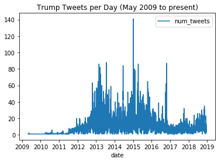

```python
# plot the number of tweets each day
plt.figure()
daily_tweets_plot = tweets_by_date.plot()
daily_tweets_plot.set_title("Trump Tweets per Day (May 2009 to present)")
```

Before running for president, there were a few major spikes in Trump’s tweets. It is not immediately clear to me what caused the spikes, and I am primarily concerned with the other time periods, so I will ignore them.

```
Text(0.5,1,'Trump Tweets per Day (May 2009 to June 2015)')
```

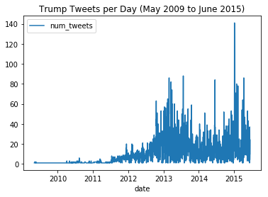

```python
# plot tweets per day in the pre-candidacy period
pre_campaign_tweet_counts = tweets_by_date.loc[datetime.date(2009, 5, 4) : datetime.date(2015, 6, 16)]

plt.figure()
pre_campaign_daily_tweets_plot = pre_campaign_tweet_counts.plot()
pre_campaign_daily_tweets_plot.set_title("Trump Tweets per Day (May 2009 to June 2015)")
```

```
Text(0.5,1,'Trump Tweets per Day (June 2015 to November 2016)')
```

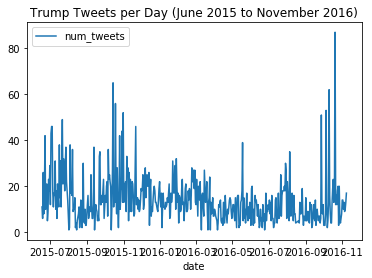

```python
# plot tweets per day while Trump was campaigning for president
candidacy_tweet_counts = tweets_by_date.loc[datetime.date(2015, 6, 17) : datetime.date(2016, 11, 8)]

plt.figure()
candidacy_daily_tweets_plot = candidacy_tweet_counts.plot()
candidacy_daily_tweets_plot.set_title("Trump Tweets per Day (June 2015 to November 2016)")
```

This graph covers a very small time period (only about 2 ½ months), and it is incredibly jagged with plenty of spikes all over the place, so I don’t think I can draw any conclusions.

```
Text(0.5,1,'Trump Tweets per Day (November 2016 to January 2017)')
```

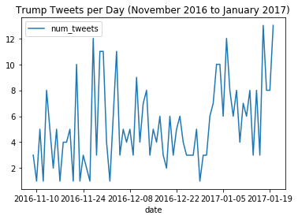

```python
# plot tweets per day while Trump was president-elect
president_elect_tweet_counts = tweets_by_date.loc[datetime.date(2016, 11, 9) : datetime.date(2017, 1, 20)]

plt.figure()
president_elect_daily_tweets_plot = president_elect_tweet_counts.plot()
president_elect_daily_tweets_plot.set_title("Trump Tweets per Day (November 2016 to January 2017)")
```

Finally, during Trump’s presidency, there are two major spikes that stand out to me: one that took place in September of 2017, and one that took place in early November of 2018. The first of the spikes lines up quite well with Trump’s ending of the DACA ([Deferred Action for Childhood Arrivals](https://en.wikipedia.org/wiki/Deferred_Action_for_Childhood_Arrivals)) program, a move which drew very heavy criticism. Similarly, the second spike falls right around the [2018 midterm election](https://en.wikipedia.org/wiki/2018_United_States_elections), in which the Democratic Party won control of the United States House of Representatives. It makes sense that Trump would be quite vocal about his political opponents gaining ground in the United States government.

```
Text(0.5,1,'Trump Tweets per Day (January 2017 to present)')
```

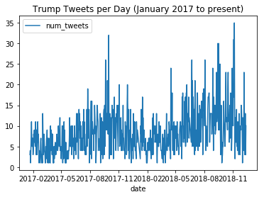

```python
# plot tweets per day while Trump has been president
president_tweet_counts = tweets_by_date.loc[datetime.date(2017, 1, 21) :]

plt.figure()
president_daily_tweets_plot = president_tweet_counts.plot()
president_daily_tweets_plot.set_title("Trump Tweets per Day (January 2017 to present)")
```

In conclusion, based on the last five graphs, I think that attempting to identify major events based on Trump’s volume of tweets on those days is very hit-or-miss. Some events lined up with spikes in Trump’s tweeting, but roughly as many spikes had no clear corresponding event. Going forward, there are certainly additional details that I could have gathered, perhaps by parsing Trump tweets on the days in question for key words that could relate to a certain event. Obviously, using a word cloud to identify key words is only the first step in analyzing Trump’s speech patterns. I wonder what kinds of insights I may gain from incorporating natural language processing into this project, so I may attempt that over winter break.